# Geospatial Analysis Final Project

Aranxa Márquez Ampudia & Milton Mier Santander

2025-05-14

# Getting the data

### Load indicators data

```r
# Load data
zip_filename <- "final_df.zip"
csv_filename <- "../final_df.csv"

# Temporary directory
temp_dir <- tempdir()

# Extract the specific CSV file to temp dir
unzip(zipfile = zip_filename, files = csv_filename, exdir = temp_dir)

# Extracted file will retain directory structure, verify exact path:
extracted_file_path <- file.path(temp_dir, csv_filename)

# Normalize path (since "../" could cause issues)
extracted_file_path <- normalizePath(extracted_file_path, mustWork = FALSE)

# Check if extraction succeeded:
if (!file.exists(extracted_file_path)) {
    stop("Extraction failed. Check filenames and paths.")
}

# Read the CSV into a dataframe
final_df <- read.csv(extracted_file_path)

# Clean up by deleting the file
file.remove(extracted_file_path)
```

```
## [1] TRUE
```

```r
head(final_df)
```

```
##   codmpio cluster_kmeans Departamento Municipio Region year   f_loss    pc_loss
## 1    5001              2    ANTIOQUIA  MEDELLIN Andina 2010 30.15442 0.07791839
## 2    5001              2    ANTIOQUIA  MEDELLIN Andina 2011 25.69562 0.06639694
## 3    5001              2    ANTIOQUIA  MEDELLIN Andina 2012 29.34525 0.07582751
## 4    5001              2    ANTIOQUIA  MEDELLIN Andina 2013 18.41223 0.04757681
## 5    5001              2    ANTIOQUIA  MEDELLIN Andina 2014 43.50983 0.11242849
## 6    5001              2    ANTIOQUIA  MEDELLIN Andina 2015 13.65733 0.03529026
##   areaoficialhm2      gdp   gdp_pc        iica fisc_perf discapital dismdo
## 1          38700 29640832 12.65054 0.012095839     89.43          0      0
## 2          38700 34442533 14.54326 0.013449685     84.36          0      0
## 3          38700 36924720 15.43023 0.011285927     83.22          0      0
## 4          38700 40880874 16.91162 0.008260538     84.82          0      0
## 5          38700 43042337 17.63219 0.006920000     85.50          0      0
## 6          38700 45551405 18.48436 0.005630000     83.73          0      0
##   disbogota pobl_rur pobl_urb total_ac total_as total_p total_r total_nuf
```

[output cut: 90 more lines]

### Load geospatial data

```r
# Read GeoJSON
muni_sf <- geojson_sf("colombia_municipios_poblacion.json")
head(muni_sf)
```

```
## Simple feature collection with 6 features and 10 fields
## Geometry type: MULTIPOLYGON
## Dimension:     XY
## Bounding box:  xmin: -76.10266 ymin: 0.9765178 xmax: -74.89546 ymax: 2.32638
## Geodetic CRS:  WGS 84
##   DPTO_CCDGO MPIO_CCDGO             MPIO_CNMBR MPIO_CDPMP VERSION       AREA
## 1         18        001              FLORENCIA      18001    2018 2547637532
## 2         18        029                ALBANIA      18029    2018  414122070
## 3         18        094 BELÉN DE LOS ANDAQUÍES      18094    2018 1191618572
## 4         18        247            EL DONCELLO      18247    2018 1106076151
## 5         18        256              EL PAUJÍL      18256    2018 1234734145
## 6         18        410           LA MONTAÑITA      18410    2018 1701061430
##    LATITUD  LONGITUD TSP16_HOG STP27_PERS                       geometry
## 1 1.749139 -75.55824     51430     156789 MULTIPOLYGON (((-75.40406 1...
## 2 1.227865 -75.88233      1559       4514 MULTIPOLYGON (((-75.75674 1...
## 3 1.500923 -75.87565      3161       9075 MULTIPOLYGON (((-75.77891 1...
## 4 1.791386 -75.19394      6129      17775 MULTIPOLYGON (((-75.34871 2...
## 5 1.617746 -75.23404      5848      13014 MULTIPOLYGON (((-74.96432 1...
## 6 1.302860 -75.23573      3748      12128 MULTIPOLYGON (((-75.08149 1...
```

```r
## Assigning manually the Coordinate Reference System (CRS)
st_crs(muni_sf) <- 4326

# Check number of geometries in original shapefile
nrow(muni_sf)
```

```
## [1] 1122
```

```r
# Check number of records in final_df
nrow(final_df)
```

```
## [1] 14710
```

```r
# Check join key overlap
length(intersect(muni_sf$MPIO_CDPMP, final_df$codmpio))
```

```
## [1] 970
```

# Preparing the data

```r
# Convert both codes to character to ensure matching works
final_df <- final_df %>%
  mutate(codmpio = as.character(codmpio))

muni_sf <- muni_sf %>%
  mutate(MPIO_CCDGO = as.character(MPIO_CDPMP))
```

```r
# Filter for 2022

final_22 <- final_df %>%
  filter(year == 2022)
```

```r
# Clean names
muni_sf <- muni_sf %>%
  mutate(MPIO_CCDGO = str_pad(as.character(MPIO_CDPMP), width = 5, pad = "0"))

final_22 <- final_22 %>%
  mutate(codmpio = str_pad(as.character(codmpio), width = 5, pad = "0"))
```

```r
# Join data sets
joined_sf <- left_join(muni_sf, final_22, by = c("MPIO_CDPMP" = "codmpio"))
```

# Spatial Autocorrelation

## 1. Handling missing values

```r
# drop all areas with NA values
joined_sf <- joined_sf |> filter(!is.na(iica))
```

## 2. Visualizing Conflict Incidence (iica)

We visualized the distribution of the conflict index (iica) across Colombian municipalities using a choropleth map. The color gradient represents normalized conflict intensity, ranging from low (dark purple) to high (yellow).

```r
# 1. Load Colombia + neighbors
world <- ne_countries(scale = "medium", returnclass = "sf")
neighbors_sf <- world %>%
  filter(admin %in% c("Panama", "Ecuador", "Peru", "Brazil", "Venezuela"))

# Manually adjusted label position
manual_labels <- data.frame(
  admin = c("Panama", "Ecuador", "Peru", "Brazil", "Venezuela"),
  lon = c(-80.5, -78.5, -75.8, -66.0, -67.0),
  lat = c(10.3, -1.0, -5.0, -1.5, 9.5)
)

manual_labels_sf <- st_as_sf(manual_labels, coords = c("lon", "lat"), crs = st_crs(neighbors_sf))

# 3. Create bounding box around Colombia (with buffer)
colombia_bbox <- st_bbox(joined_sf) %>%
  st_as_sfc() %>%
  st_buffer(dist = 2)  # degrees; adjust if needed
```

```
## dist is assumed to be in decimal degrees (arc_degrees).
```

```r
# 4. Crop neighbors to bbox
neighbors_crop <- st_intersection(neighbors_sf, colombia_bbox)
```

```
## although coordinates are longitude/latitude, st_intersection assumes that they
## are planar
```

```
## ── tmap v3 code detected ───────────────────────────────────────────────────────
```

[output not shown]

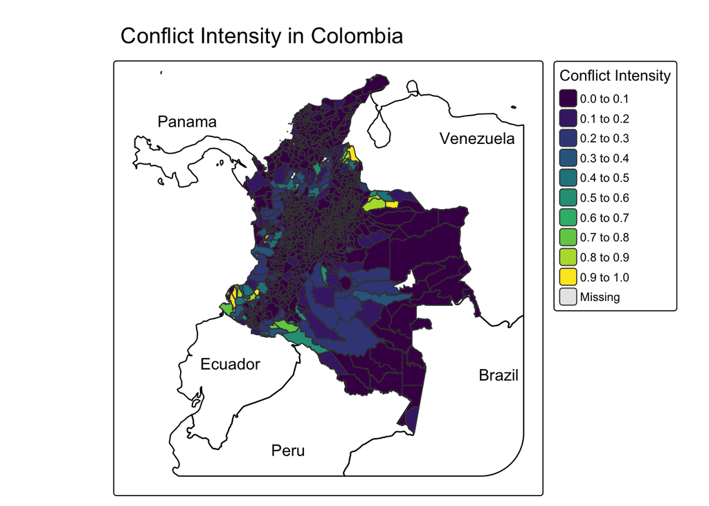

```r
# 5. Remove any missing values from joined_sf
joined_sf_clean <- joined_sf %>% filter(!is.na(iica))

# 6. Plot the map
tmap_options(component.autoscale = FALSE)

tm_shape(neighbors_crop) +
  tm_borders(col = "black", lwd = 1.2) +

tm_shape(joined_sf_clean, is.master = TRUE) +
  tm_polygons(
    col = "iica",
    palette = "viridis",
    n = 10,
    title = "Conflict Intensity",
    na.value = NA,
    legend.show.na = FALSE
  ) +

tm_shape(manual_labels_sf) +
  tm_text("admin", size = 0.95, col = "black", fontface = "plain") +

tm_layout(
  main.title = "Conflict Intensity in Colombia",
  legend.outside = TRUE,
  legend.outside.position = "right",
  outer.margins = c(0.02, 0.15, 0.02, 0.02),
  inner.margins = c(0.05, 0.05, 0.05, 0.05)
)
```

This map reveals clear spatial heterogeneity in conflict levels, with notable clusters of high intensity in the Pacific region, southern Colombia, and areas near the Venezuelan and Ecuador’s border. These visual patterns suggest the presence of spatial autocorrelation, which we test formally in the next section using Moran’s I statistic.

## Spatial Autocorrelation Test — Moran’s I

To formally assess the presence of spatial autocorrelation in conflict incidence, we computed Moran’s I statistic using a spatial weights matrix (nbw) based on *municipality contiguity*. The test evaluates whether similar values of iica (conflict intensity) cluster together in space more than expected by chance.

```r
# first we again define the neighbors
# in this case, we consider direct neighbors
nb <- poly2nb(joined_sf, queen = TRUE)
```

```
## although coordinates are longitude/latitude, st_intersects assumes that they
## are planar
```

```r
# the we create weights for the neighbors with style: row standardized
nbw <- nb2listw(nb, style = "W", zero.policy = T)

# we set our hypothesis to: alternative to "greater", which means we expect positive autocorrelation
gmoran <- moran.test(joined_sf$iica, nbw,
                     alternative = "greater")

gmoran
```

```
##
##  Moran I test under randomisation
##
## data:  joined_sf$iica
## weights: nbw
## n reduced by no-neighbour observations
##
## Moran I statistic standard deviate = 30.262, p-value < 2.2e-16
## alternative hypothesis: greater
## sample estimates:
## Moran I statistic       Expectation          Variance
##      0.5319329286     -0.0008865248      0.0003099949
```

## Interpretation

The Moran’s I value of 0.53 is strongly positive, indicating a high degree of spatial clustering in conflict levels.

The p-value < 2.2e-16 confirms this result is statistically significant — therefore, we reject the null hypothesis of spatial randomness.

This justifies the use of spatial regression models in the next steps, as standard OLS would violate the independence assumption.

# Moran’s I Scatterplot

To visualize the spatial autocorrelation in conflict incidence, we visualized a Moran’s scatterplot, which compares each municipality’s conflict value (iica) to the spatially lagged average of its neighbors.

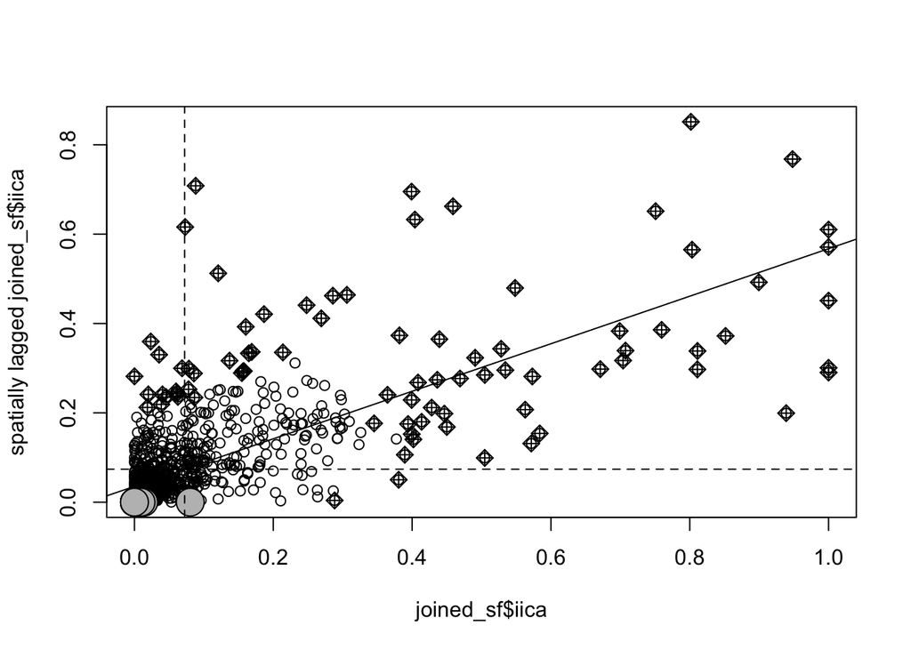

```r
mp <- moran.plot(joined_sf$iica, nbw, labels=F)
```

```r
# spatially lagged values: mp$wx
```

This plot is divided into four quadrants:

- *Top right (High–High):* Municipalities with high conflict levels surrounded by others with high conflict.
- *Bottom left (Low–Low):* Municipalities with low conflict levels surrounded by others with low conflict.
- *Top left (Low–High):* Municipalities with low conflict values, but surrounded by high-conflict neighbors (potential outliers or transition zones).
- *Bottom right (High–Low):* Municipalities with high conflict values but low-conflict neighbors.

The upward-sloping line confirms the positive spatial autocorrelation already identified through Moran’s I — municipalities tend to resemble their neighbors in terms of conflict intensity.

## Local Indicators of Spatial Associatiom (LISA) using Local Moran’s I

To further explore where spatial autocorrelation occurs, we computed Local Moran’s I statistics. While the global Moran’s I indicates whether clustering exists overall, Local Moran’s I identifies specific municipalities that exhibit *significant local clustering of conflict levels*.

```r
lmoran <- localmoran(joined_sf$iica, nbw, alternative = "two.sided")
head(lmoran)
```

```
##            Ii          E.Ii      Var.Ii       Z.Ii Pr(z != E(Ii))
## 1 -0.06563762 -5.155360e-05 0.007242827 -0.7706506      0.4409141
## 2  0.06741570 -2.212445e-05 0.006238927  0.8537852      0.3932240
## 3 -0.01248418 -3.916942e-05 0.006294779 -0.1568574      0.8753573
## 4 -0.11563313 -1.007339e-04 0.022703000 -0.7667648      0.4432214
## 5  0.28122076 -3.725171e-04 0.059845950  1.1510784      0.2497000
## 6  1.52452268 -1.140249e-02 2.540799354  0.9635736      0.3352598
```

```r
joined_sf$lmI <- lmoran[, "Ii"] # local Moran's I
# p-values corresponding to alternative greater
joined_sf$lmp <- lmoran[, "Pr(z != E(Ii))"]
joined_sf$lmI_sign <- joined_sf$lmI
#joined_sf[joined_sf$lmp >= 0.05, "lmI_sign"] <- NA
```

```r
## Visualize statistical significant values
tm_shape(joined_sf) +
  tm_polygons(
    fill = "lmI_sign",
    fill.scale = tm_scale_intervals(
      breaks = c( -5, 0, 5, 10, 15, 20, 25, 30, 35),
      labels = c( "-5 to 0", "0 to 5", "5 to 10",
        "10 to 15", "15 to 20", "20 to 25", "25 to 30", "30 to 35"
      ),
      values = colorRampPalette(c("purple", "gray90", "darkgreen"))(14),
      label.na = "Not Significant"
    ),
    fill.legend = tm_legend(title = "Local Moran's I")
  ) +
  tm_title("Local Moran’s I: Spatial Autocorrelation")
```

```
## [scale] tm_polygons:() the data variable assigned to 'fill' contains positive and negative values, so midpoint is set to 0. Set 'midpoint = NA' in 'fill.scale = tm_scale_intervals(<HERE>)' to use all visual values (e.g. colors)
```

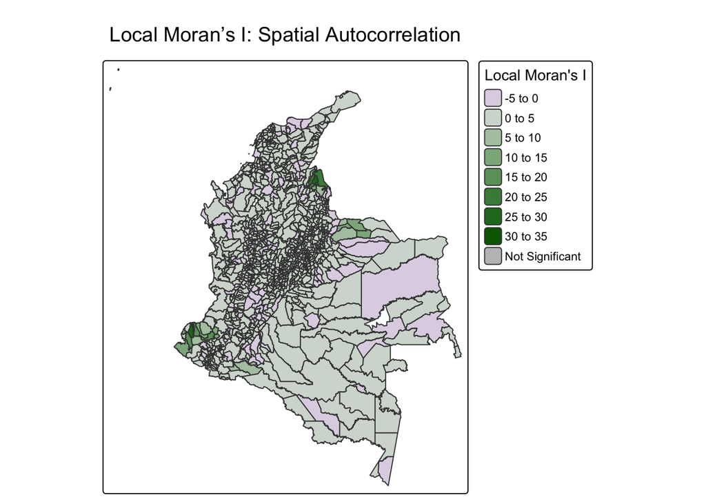

### Local Moran’s I: Spatial Autocorrelation

```r
tm_shape(joined_sf) +
  tm_polygons(
    fill = "lmI_sign",
    fill.scale = tm_scale(
      breaks = c(min(joined_sf$lmI_sign, na.rm = TRUE), 0, max(joined_sf$lmI_sign, na.rm = TRUE)),
      labels = c("Negative SAC", "Positive SAC"),
      textNA = "Not Significant"
    )
  ) +
  tm_title("Spatial Autocorrelation (Positive and Negative Clusters)")
```

```
## [scale] tm_polygons:() the data variable assigned to 'fill' contains positive and negative values, so midpoint is set to 0. Set 'midpoint = NA' in 'fill.scale = tm_scale_intervals(<HERE>)' to use all visual values (e.g. colors)
```

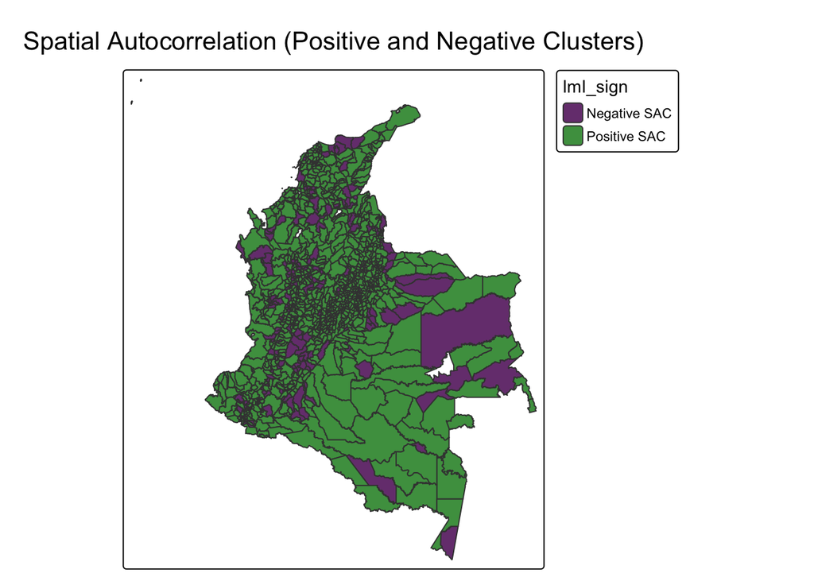

### Interpretation

- Positive spatial autocorrelation dominates, especially in conflict-heavy regions like the Pacific and northeast.
- This confirms that conflict incidence is not randomly distributed, but spatially clustered.
- These spatial patterns help justify the need for regional policy coordination and the use of spatial econometric models in the next section.

# Identifying Local Spatial Clusters

To better understand how conflict clusters spatially, we classified municipalities using Local Moran’s I quadrants. This typology helps distinguish between core hotspots, outliers, and areas of low conflict intensity.

Quadrant Categories:

- High–High (Hotspots): Municipalities with high conflict, surrounded by high-conflict neighbors.
- Low–Low (Coldspots): Low-conflict municipalities surrounded by similarly low-conflict areas.
- Low–High (Spatial Outliers): Low-conflict municipalities surrounded by high-conflict neighbors.
- High–Low (Spatial Outliers): High-conflict municipalities surrounded by low-conflict neighbors.
- Non-significant: No statistically significant local autocorrelation (p ≥ 0.05).

# Visualisations

```r
# scale such that mean is 0
#mp <- moran.plot(as.vector(scale(la_income$estimate)), nbw)
# get quadrant information
joined_sf$quadr <- attributes(lmoran)$quadr$mean
levels(joined_sf$quadr) <- c(levels(joined_sf$quadr), "non-significant")
joined_sf[(joined_sf$lmp >= 0.05) & !is.na(joined_sf$lmp), "quadr"] <- "non-significant"
```

## Significant quadrants

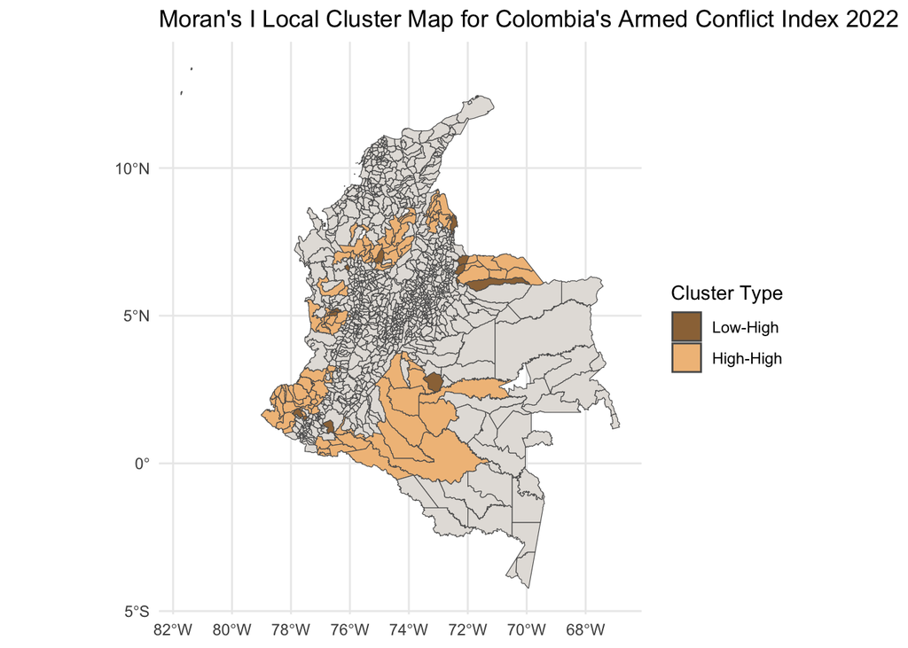

```r
ggplot(joined_sf) +
  geom_sf(aes(fill = quadr)#, color = NA
          ) +
  scale_fill_manual(
    values = c("High-High" = "#f1bf88","Low-High" = "#9c7346"),
    na.value = "#e4e0dc"
  ) +
  labs(
    title = "Moran's I Local Cluster Map for Colombia's Armed Conflict Index 2022",
    fill = "Cluster Type"
  ) +
  theme_minimal()
```

Note: Only significant clusters (p<0.05) are shown.

This map highlights regional conflict hotspots in:

- The Pacific coast, southwest, and northeast, dominated by High–High clusters, indicating strong and persistent spatial patterns of violence.
- Some municipalities appear as spatial outliers (Low–High or High–Low), possibly signaling transitional or volatile zones.

## Distribution of the Outcome Variable

We first examined the distribution of the outcome variable, **iica** — an index measuring armed conflict incidence at the municipal level in 2022.

As shown in the histogram, the distribution of **iica** is heavily right-skewed, with the vast majority of municipalities reporting very low conflict levels and a long tail of high values. This violates the normality assumption of linear models.

Log Transformation: To normalize the distribution and improve model fit, we applied a log transformation to **iica**:

The log-transformed outcome is much closer to a normal distribution, making it more suitable for regression analysis. This transformation also helps interpret model coefficients in terms of proportional effects on conflict intensity.

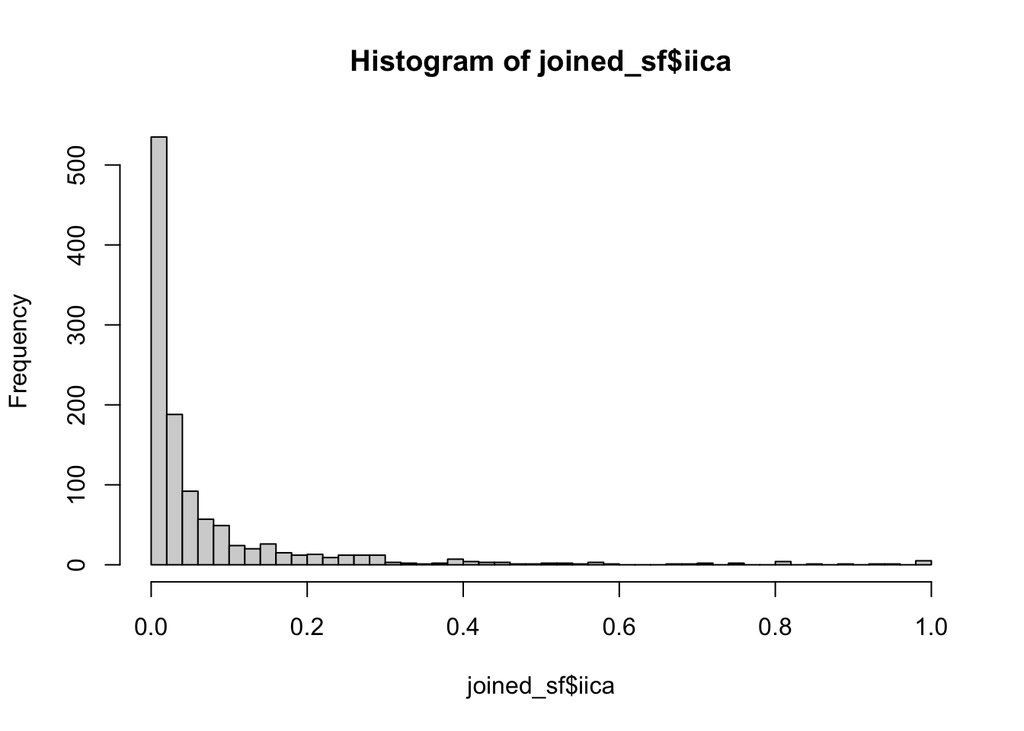

```r
hist(joined_sf$iica, nclass=50)
```

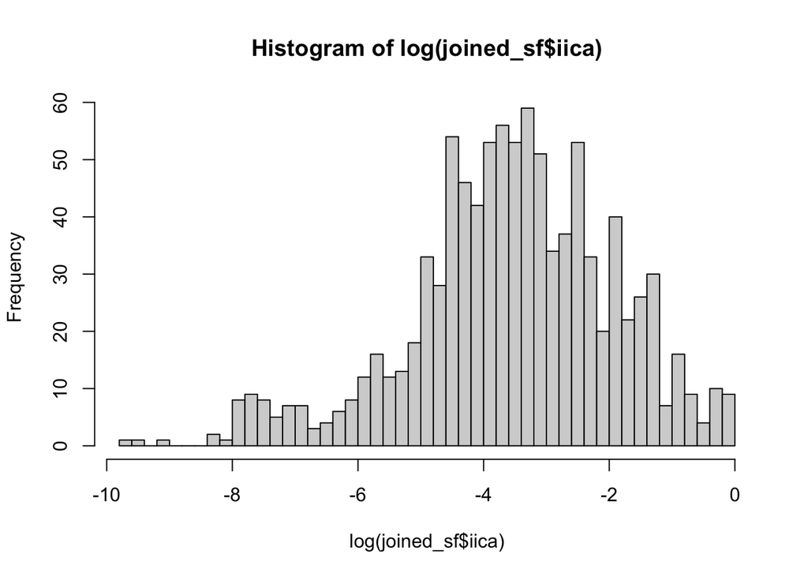

```r
hist(log(joined_sf$iica), nclass=50)
```

# Regression models

## Initial (Non-Spatial) Regression Model

We first estimated a baseline linear regression model to assess whether municipal-level socio-economic indicators predict conflict intensity **(log(iica))**.

- Significant predictors: coca cultivation, displacement, and GDP per capita.
- Model fit: R² = 0.13 (modest explanatory power).
- Assumptions: The residuals show patterns of spatial autocorrelation, indicating a violation of the independence assumption.

```r
# Filter rows without NAs (just in case)
joined_clean <- joined_sf %>%
  filter(!is.na(iica), iica > 0) %>%
  filter(!is.na(gdp_pc)) %>%
  filter(!is.na(H_coca)) %>%
  filter(!is.na(fisc_perf)) %>%
  filter(!is.na(e_desplaza))

joined_clean2 <- joined_clean |>
  na.omit()

# this is our initial regression model
formula <- formula(log(iica) ~ gdp_pc + H_coca + fisc_perf + e_desplaza)

model1 <- lm(formula = formula, data = joined_clean, na.action = na.omit)
summary(model1)
```

```
##
## Call:
## lm(formula = formula, data = joined_clean, na.action = na.omit)
##
## Residuals:
##     Min      1Q  Median      3Q     Max
## -6.0271 -0.7721  0.1546  1.0473  3.7495
##
## Coefficients:
##               Estimate Std. Error t value Pr(>|t|)
## (Intercept) -3.199e+00  2.646e-01 -12.090  < 2e-16 ***
## gdp_pc      -3.836e-03  1.510e-03  -2.540   0.0112 *
## H_coca       2.707e-04  4.014e-05   6.743 2.67e-11 ***
## fisc_perf   -6.977e-03  4.538e-03  -1.538   0.1245
## e_desplaza   2.091e-04  3.511e-05   5.954 3.66e-09 ***
## ---
## Signif. codes:  0 '***' 0.001 '**' 0.01 '*' 0.05 '.' 0.1 ' ' 1
##
## Residual standard error: 1.531 on 962 degrees of freedom
## Multiple R-squared:  0.1335, Adjusted R-squared:  0.1299
## F-statistic: 37.05 on 4 and 962 DF,  p-value: < 2.2e-16
```

# Spatial Autocorrelation of Residuals

To assess whether spatial dependence remains in the residuals of the non-spatial regression model, we applied Moran’s I test.

### Results

Moran’s I = 0.367 p-value < 2.2e-16 Statistically significant positive spatial autocorrelation This result confirms that the residuals are not randomly distributed in space, violating the assumption of independence and suggesting spatial spillover effects.

## Residuals vs. Lagged Residuals Plot

The upward trend in this scatterplot supports the Moran’s I result, showing that municipalities with high (or low) residuals tend to be surrounded by neighbors with similar residuals. Conclusion: A spatial regression model is needed to capture this remaining autocorrelation.

```r
# create list of neighbors
wts <- joined_clean |>
  poly2nb() |>
  nb2listw(style = "W", zero.policy = T)
```

```
## although coordinates are longitude/latitude, st_intersects assumes that they
## are planar
```

```r
# use Morans I test if there is still autocorrelation in our residuals
moran.test(model1$residuals, wts)
```

```
##
##  Moran I test under randomisation
##
## data:  model1$residuals
## weights: wts
## n reduced by no-neighbour observations
##
## Moran I statistic standard deviate = 18.008, p-value < 2.2e-16
## alternative hypothesis: greater
## sample estimates:
## Moran I statistic       Expectation          Variance
##      0.3671523897     -0.0010395010      0.0004180197
```

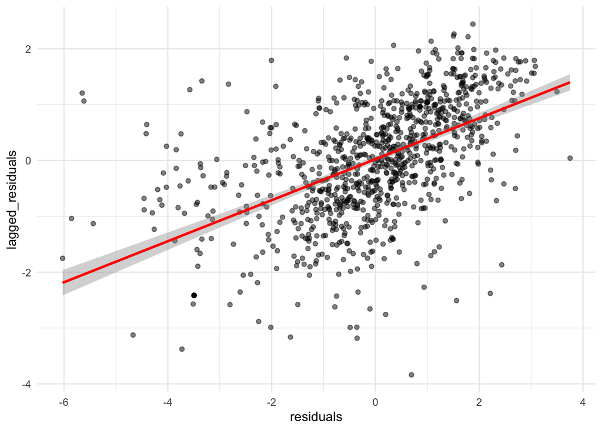

```r
residuals_model1 <- residuals(model1)
lagged_residuals_model1 <- lag.listw(wts, residuals_model1)

res <- data.frame("lagged_residuals"=lagged_residuals_model1, "residuals"=residuals_model1)

ggplot(res, aes(x = residuals, y = lagged_residuals)) +
  theme_minimal() +
  geom_point(alpha = 0.5) +
  geom_smooth(method = "lm", color = "red")
```

## 1. Spatially Lagged X Model (SLX)

To account for potential spatial spillovers of the independent variables, we estimated an SLX model, which augments the standard OLS specification by including spatially lagged covariates.

### Key Findings

The analysis reveals several significant predictors of conflict at the municipal level. Coca cultivation is strongly associated with higher conflict: both local cultivation **(H_coca, p = 0.0027)** and cultivation in neighboring municipalities **(lag.H_coca, p = 0.0027)** significantly increase conflict intensity. This suggests that coca-related dynamics are not only locally impactful but also diffuse across municipal borders.

Similarly, forced displacement plays a significant role. An increase in displacement within a municipality **(e_desplaza, p < 0.0001)** and in neighboring areas **(lag.e_desplaza, p < 0.000000001)** both correspond to heightened conflict levels, indicating that displacement may both reflect and reinforce conflict patterns across space.

### Interpretation

```r
vars_used <- all.vars(formula(model1))  # Includes dependent + independent variables
summary(joined_clean[, vars_used])      # Check for NAs, negative values, etc.
```

```
##       iica             gdp_pc           H_coca          fisc_perf
##  Min.   :0.00006   Min.   :  2.73   Min.   :    0.0   Min.   : 5.984
##  1st Qu.:0.01145   1st Qu.: 11.10   1st Qu.:    0.0   1st Qu.:52.511
##  Median :0.03017   Median : 16.50   Median :    0.0   Median :58.668
##  Mean   :0.08453   Mean   : 23.44   Mean   :  258.1   Mean   :57.586
##  3rd Qu.:0.08464   3rd Qu.: 24.45   3rd Qu.:    0.0   3rd Qu.:64.229
##  Max.   :1.00000   Max.   :547.44   Max.   :22081.5   Max.   :90.065
##    e_desplaza               geometry
##  Min.   :    0.0   MULTIPOLYGON :967
##  1st Qu.:    5.0   epsg:4326    :  0
##  Median :   30.0   +proj=long...:  0
##  Mean   :  327.8
##  3rd Qu.:  170.0
##  Max.   :36668.0
```

```r
class(joined_clean)
```

```
## [1] "sf"         "data.frame"
```

```r
# Should include "sf"

library(spatialreg)

formula <- formula(log(iica) ~ gdp_pc + H_coca + fisc_perf + e_desplaza)

# SLX model (includes spatial lags of X variables only)
slx_model <- lmSLX(formula, data = joined_clean, listw = wts, zero.policy = TRUE)
summary(slx_model)
```

```
##
## Call:
## lm(formula = formula(paste("y ~ ", paste(colnames(x)[-1], collapse = "+"))),
##     data = as.data.frame(x), weights = weights)
##
## Coefficients:
##                 Estimate    Std. Error  t value     Pr(>|t|)
## (Intercept)     -2.552e+00   4.106e-01  -6.215e+00   7.631e-10
## gdp_pc          -9.728e-04   1.612e-03  -6.037e-01   5.462e-01
## H_coca           1.355e-04   4.509e-05   3.006e+00   2.719e-03
## fisc_perf       -6.318e-03   4.481e-03  -1.410e+00   1.589e-01
## e_desplaza       1.514e-04   3.459e-05   4.376e+00   1.339e-05
## lag.gdp_pc      -4.575e-03   2.785e-03  -1.642e+00   1.008e-01
## lag.H_coca       2.094e-04   6.961e-05   3.008e+00   2.698e-03
## lag.fisc_perf   -1.397e-02   6.864e-03  -2.035e+00   4.209e-02
## lag.e_desplaza   4.112e-04   6.651e-05   6.183e+00   9.302e-10
```

### a) Direct and Indirect Effects

To better interpret the coefficients of the SLX model, we compute impacts, which decompose the estimated effects into: - Direct effects: The impact of a predictor on conflict within the same municipality. - Indirect effects (spillovers): The effect of that predictor in neighboring municipalities. - Total effect: Sum of direct + indirect.

### b) Summary of Impacts

The decomposition of effects reveals that coca cultivation **(H_coca)** and forced displacement **(e_desplaza)** both have statistically significant impacts on conflict, not only within municipalities but also through spatial spillovers. Specifically, coca cultivation shows a direct effect of **+0.00014** and an indirect (spillover) effect of +0.00021, resulting in a total effect of **+0.00035**. Similarly, forced displacement has a direct effect of +0.00015 and an indirect effect of **+0.00041**, leading to a total effect of **+0.00056**. These results underscore the spatial diffusion of conflict drivers: activities in one municipality influence conflict levels in neighboring areas.

### c) Interpretation

```r
summary(impacts(slx_model))
```

```
## Impact measures (SlX, glht, n-k):
##                   Direct      Indirect         Total
## gdp_pc     -0.0009728446 -0.0045748977 -0.0055477423
## H_coca      0.0001355257  0.0002093840  0.0003449097
## fisc_perf  -0.0063175944 -0.0139703782 -0.0202879726
## e_desplaza  0.0001513731  0.0004112157  0.0005625888
## ========================================================
## Standard errors:
##                  Direct     Indirect        Total
## gdp_pc     1.611568e-03 2.785346e-03 2.545866e-03
## H_coca     4.509008e-05 6.960686e-05 6.100614e-05
## fisc_perf  4.480711e-03 6.863852e-03 7.317838e-03
## e_desplaza 3.458806e-05 6.650833e-05 6.690218e-05
## ========================================================
## Z-values:
##                Direct  Indirect     Total
## gdp_pc     -0.6036635 -1.642488 -2.179118
## H_coca      3.0056660  3.008094  5.653688
## fisc_perf  -1.4099535 -2.035355 -2.772400
## e_desplaza  4.3764542  6.182920  8.409125
##
## p-values:
##            Direct     Indirect   Total
## gdp_pc     0.54607    0.1004889  0.0293229
## H_coca     0.00265    0.0026289  1.5704e-08
## fisc_perf  0.15855    0.0418151  0.0055645
## e_desplaza 1.2063e-05 6.2926e-10 < 2.22e-16
```

## Moran’s Test on SLX model Residuals

To verify whether the SLX model sufficiently accounts for spatial dependence, we ran Moran’s I test on its residuals.

```r
moran.test(slx_model$residuals, wts)
```

```
##
##  Moran I test under randomisation
##
## data:  slx_model$residuals
## weights: wts
## n reduced by no-neighbour observations
##
## Moran I statistic standard deviate = 16.927, p-value < 2.2e-16
## alternative hypothesis: greater
## sample estimates:
## Moran I statistic       Expectation          Variance
##      0.3450587382     -0.0010395010      0.0004180411
```

### Result

Moran’s I statistic: 0.346 p-value: < 2.2e-16

### Conclusion

Residuals still exhibit significant positive spatial autocorrelation.

### Interpretation

Despite including spatially lagged predictors, the SLX model fails to fully capture spatial dependence. This suggests the need for models that account for spatial dependence in the dependent variable or error term, such as the SAR (spatial lag) or SEM (spatial error) models.

## 2. Spatial Lag Model (SAR)

To address the limitations of the SLX model, we estimate a Spatial Lag Model (SAR) using Maximum Likelihood.

### Key Findings

Spatial dependence (Rho) is strong and highly significant: ρ = 0.576, p < 0.001 → confirms that conflict levels in neighboring municipalities are positively correlated. Significant predictors: H_coca (Coca cultivation): positive effect, p < 0.001 e_desplaza (Forced displacement): positive effect, p < 0.001 gdp_pc and fisc_perf are not significant

### Model fit improvements

AIC reduced from 3574.7 (OLS) to 3289.6 (SAR) Nagelkerke pseudo-R² = 0.356

### Remaining issues

LM test for residual autocorrelation still significant **(p < 0.001)** → suggests some spatial structure remains in the residuals.

### Interpretation

This model captures spatial spillover in the dependent variable, indicating that conflict intensity is not only influenced by local conditions but also by those in adjacent municipalities. However, residual autocorrelation persists—motivating exploration of a Spatial Error Model (SEM) next.

```r
# spatial lag models
lag_model <- lagsarlm(
  formula = formula,
  data = joined_clean,
  listw = wts, # taking the same weights as before
  zero.policy = T
  )
summary(lag_model, Nagelkerke = TRUE)
```

```
##
## Call:lagsarlm(formula = formula, data = joined_clean, listw = wts,
##     zero.policy = T)
##
## Residuals:
##      Min       1Q   Median       3Q      Max
## -5.22869 -0.55706  0.16034  0.79335  3.60493
##
## Type: lag
## Regions with no neighbours included:
##  613 614 646 667
## Coefficients: (asymptotic standard errors)
##                Estimate  Std. Error z value  Pr(>|z|)
## (Intercept) -1.4272e+00  2.4651e-01 -5.7898 7.047e-09
## gdp_pc      -1.7196e-03  1.2516e-03 -1.3739    0.1695
## H_coca       1.4371e-04  3.3601e-05  4.2771 1.894e-05
## fisc_perf   -2.6434e-03  3.7548e-03 -0.7040    0.4814
## e_desplaza   1.3278e-04  2.9116e-05  4.5602 5.110e-06
##
## Rho: 0.57563, LR test value: 287.16, p-value: < 2.22e-16
## Asymptotic standard error: 0.031756
##     z-value: 18.127, p-value: < 2.22e-16
## Wald statistic: 328.57, p-value: < 2.22e-16
##
## Log likelihood: -1637.789 for lag model
## ML residual variance (sigma squared): 1.6047, (sigma: 1.2668)
## Nagelkerke pseudo-R-squared: 0.35611
## Number of observations: 967
## Number of parameters estimated: 7
## AIC: 3289.6, (AIC for lm: 3574.7)
## LM test for residual autocorrelation
## test value: 32.965, p-value: 9.3845e-09
```

The spatial lag model includes both direct and indirect (spillover) effects of predictors on conflict intensity (log-transformed **iica**). The estimated spatial autoregressive coefficient **(p = 0.576, p < 0.001)** indicates a strong and significant spatial dependence, justifying the model choice.

Direct effects reflect the impact within a municipality, while indirect effects capture spillover effects on neighboring municipalities. Total effects are the sum of both.

Interpretation **H_coca** and **e_desplaza** have statistically significant total effects, indicating both local and spillover influences on conflict intensity. **gdp_pc** and **fisc_perf** do not exhibit statistically significant effects under this model. The spatial lag (p) is strong and significant, validating the presence of spatial dependence in the outcome.

```r
imp <- impacts(lag_model, listw = wts, R=100) # compute impacts
imp
```

```
## Impact measures (lag, exact):
##                   Direct      Indirect         Total
## gdp_pc     -0.0018737335 -0.0021784826 -0.0040522161
## H_coca      0.0001565926  0.0001820612  0.0003386538
## fisc_perf  -0.0028802546 -0.0033487070 -0.0062289616
## e_desplaza  0.0001446739  0.0001682040  0.0003128779
```

```r
#To print the p values
summary(imp, zstats=T)$pzmat
```

```
##                  Direct     Indirect        Total
## gdp_pc     2.158494e-01 2.372216e-01 2.250533e-01
## H_coca     7.783047e-06 1.829577e-05 5.402148e-06
## fisc_perf  5.061977e-01 5.131755e-01 5.087166e-01
## e_desplaza 3.454772e-05 1.960029e-04 5.605494e-05
```

Residual Autocorrelation Check After estimating the spatial lag model, we tested the residuals for remaining spatial autocorrelation using Moran’s I.

Result: Moran’s I: -0.0509 p-value: 0.993 Interpretation: Not statistically significant.

Conclusion: The absence of spatial autocorrelation in the residuals confirms that the spatial lag model effectively captures the underlying spatial dependence in the data.

```r
moran.test(lag_model$residuals, wts)
```

```
##
##  Moran I test under randomisation
##
## data:  lag_model$residuals
## weights: wts
## n reduced by no-neighbour observations
##
## Moran I statistic standard deviate = -2.4393, p-value = 0.9926
## alternative hypothesis: greater
## sample estimates:
## Moran I statistic       Expectation          Variance
##     -0.0508938848     -0.0010395010      0.0004177021
```

## 3. Spatial Error Model (SEM)

The SEM accounts for unobserved spatial processes by modeling spatial autocorrelation in the error term, rather than in the dependent variable directly.

### Key Results

The spatial error coefficient (**lambda**) is estimated at **0.621** and is highly significant **(p < 2.2e-16)**, indicating strong evidence of spatial error dependence—that is, unobserved factors influencing conflict are spatially correlated across municipalities.

In terms of model fit, the Akaike Information Criterion (AIC) for the spatial error model is **3302.5**, which is substantially lower than the OLS model’s AIC of 3574.7, indicating a much better fit. However, it is slightly higher than the AIC for the spatial lag model (**3289.6**), suggesting the spatial lag may fit the data marginally better. The pseudo-R² of **0.347** further supports improved performance over the OLS model, which had a considerably lower R² of **0.1335**.

Regarding the significance of individual variables, both coca cultivation **(H_coca)** and forced displacement (e_desplaza) remain significant predictors of conflict, with p-values of **0.00145** and **0.0012**, respectively. In contrast, economic performance **(gdp_pc)** and fiscal performance **(fisc_perf)** are not statistically significant, with p-values of 0.3593 and 0.9383, respectively. The intercept is significant **(p < 0.001)**, reflecting a non-zero baseline level of conflict even when all predictors are at zero.

### Interpretation

The SEM improves model fit and confirms that displacement and coca cultivation are positively associated with higher conflict intensity. However, the slightly higher AIC compared to the spatial lag model suggests the lag model remains the best fit overall.

```r
error_model <- errorsarlm(
formula = formula,
data = joined_clean,
listw = wts,
zero.policy = TRUE
)
summary(error_model, Nagelkerke = TRUE)
```

```
##
## Call:errorsarlm(formula = formula, data = joined_clean, listw = wts,
##     zero.policy = TRUE)
##
## Residuals:
##      Min       1Q   Median       3Q      Max
## -5.20813 -0.56138  0.15832  0.80459  3.62655
##
## Type: error
## Regions with no neighbours included:
##  613 614 646 667
## Coefficients: (asymptotic standard errors)
##                Estimate  Std. Error  z value  Pr(>|z|)
## (Intercept) -3.6646e+00  2.4898e-01 -14.7184 < 2.2e-16
## gdp_pc      -1.2753e-03  1.3911e-03  -0.9167  0.359280
## H_coca       1.2346e-04  3.8769e-05   3.1846  0.001450
## fisc_perf    3.0174e-04  3.8951e-03   0.0775  0.938253
## e_desplaza   9.6839e-05  2.9910e-05   3.2377  0.001205
##
## Lambda: 0.62149, LR test value: 274.24, p-value: < 2.22e-16
## Asymptotic standard error: 0.031546
##     z-value: 19.701, p-value: < 2.22e-16
## Wald statistic: 388.13, p-value: < 2.22e-16
##
## Log likelihood: -1644.252 for error model
## ML residual variance (sigma squared): 1.6016, (sigma: 1.2656)
## Nagelkerke pseudo-R-squared: 0.34745
## Number of observations: 967
## Number of parameters estimated: 7
## AIC: 3302.5, (AIC for lm: 3574.7)
```

To evaluate whether the spatial error model effectively captures spatial dependence, we assess spatial autocorrelation in its residuals using Moran’s I.

### Results

Moran’s I statistic: -0.055 p-value: 0.996 Interpretation: No significant spatial autocorrelation remains in the residuals.

### Conclusion

The SEM successfully removes residual spatial dependence, confirming it is a valid model specification that appropriately accounts for latent spatial processes.

```r
moran.test(error_model$residuals, wts)
```

```
##
##  Moran I test under randomisation
##
## data:  error_model$residuals
## weights: wts
## n reduced by no-neighbour observations
##
## Moran I statistic standard deviate = -2.6425, p-value = 0.9959
## alternative hypothesis: greater
## sample estimates:
## Moran I statistic       Expectation          Variance
##     -0.0550478973     -0.0010395010      0.0004177128
```

# Model Comparison and Selection

To determine whether a spatial lag or spatial error model is more appropriate, we conducted LM tests on the OLS model residuals.

Results: LM Error (Rao’s score): 323.02, p-value < 2.2e-16 LM Lag (Rao’s score): 380.10, p-value < 2.2e-16 Interpretation: Both tests are highly significant, indicating the presence of spatial dependence. Since LM-Lag has a higher test statistic, the spatial lag model is slightly preferred over the error model in this case.

```r
lm.LMtests(
  model1,
  wts,
  test = c("LMerr", "LMlag")
  # LM error, LM lag
)
```

```
## Please update scripts to use lm.RStests in place of lm.LMtests
```

```
##
##  Rao's score (a.k.a Lagrange multiplier) diagnostics for spatial
##  dependence
##
## data:
## model: lm(formula = formula, data = joined_clean, na.action = na.omit)
## test weights: listw
##
## RSerr = 323.02, df = 1, p-value < 2.2e-16
##
##
##  Rao's score (a.k.a Lagrange multiplier) diagnostics for spatial
##  dependence
##
## data:
## model: lm(formula = formula, data = joined_clean, na.action = na.omit)
## test weights: listw
##
## RSlag = 380.1, df = 1, p-value < 2.2e-16
```

To determine the most suitable model for capturing spatial dynamics in conflict intensity, we applied the following tests:

## 1. Robust Lagrange Multiplier (LM) Tests

We ran robust versions of the LM tests to determine which spatial model is more appropriate when both LM-Lag and LM-Error are initially significant.

Only the Robust LM Lag test is statistically significant. This confirms that the spatial lag model (SAR) is the most appropriate specification for capturing spatial dependence in our data.

```r
lm.LMtests(
  model1,
  wts,
  test = c("RLMerr", "RLMlag")
  # robust LM error, robust LM lag
)
```

```
## Please update scripts to use lm.RStests in place of lm.LMtests
```

```
##
##  Rao's score (a.k.a Lagrange multiplier) diagnostics for spatial
##  dependence
##
## data:
## model: lm(formula = formula, data = joined_clean, na.action = na.omit)
## test weights: listw
##
## adjRSerr = 0.057882, df = 1, p-value = 0.8099
##
##
##  Rao's score (a.k.a Lagrange multiplier) diagnostics for spatial
##  dependence
##
## data:
## model: lm(formula = formula, data = joined_clean, na.action = na.omit)
## test weights: listw
##
## adjRSlag = 57.136, df = 1, p-value = 4.063e-14
```

These tests helped assess whether spatial dependence is best captured through a spatial lag (SAR) or a spatial error (SEM) specification. Robust LM Lag: Significant (p < 0.001) Robust LM Error: Not significant (p = 0.81)

### Interpretation

Strong evidence favors the spatial lag model (SAR), as it captures spatial spillovers in the outcome variable.

## 2. Akaike Information Criterion (AIC)

Interpretation: Both spatial models drastically outperform the non-spatial OLS baseline. The SAR model has the lowest AIC, indicating the best trade-off between fit and model complexity.

```r
AIC(model1, lag_model, error_model)
```

```
##             df      AIC
## model1       6 3574.740
## lag_model    7 3289.578
## error_model  7 3302.504
```

## Final Decision

Based on both the Robust LM tests and AIC, the spatial lag model (SAR) provides the best specification for modeling spatial dependence in municipal-level conflict intensity in Colombia.